# CS: Tulsa County 05-19

Leticia Calvillo, Fellow

Open Justice Oklahoma

2021-05-17

Background information: Why are we researching this topic? What is the expected product? A blog post? Analysis for an internal or external partner?

This project aims to shed light on the extent of medical debt in Oklahoma. The goal is to produce blog posts, fact sheets, and/or reports that emphasize the scale of the medicial debt problem in Oklahoma and urge citizens to vote in favor of SQ 802.

# 1 Data sources

Where is the data from? The ojo database? OSCN? ODCR? Crime in Oklahoma reports?

The data is from the ojo database.

## 1.1 Timeframe

What years/months are you looking at? Year of case filing, first disposition, prison admission, etc.? Be as specific as possible.

The analysis aims to identify trends in medical debt cases over the past 15 years (2005-2019).

## 1.2 Geography

What courts/counties/states are you looking at?

This analysis focuses on CS court cases in Tulsa County.

## 1.3 Variables

What variables did you use? What types of cases, crimes, etc.?

This project focuses on medical debt cases.

## 1.4 Query

If you’re using data from the OJO database, include the query you used to pull your data. This may be a function that starts `ojo_query_` or `dbGetQuery`.

```r
CS<- ojo_query_disps("TULSA", "CS", 2005:2019)
```

This gives us over 226,008 rows of data. Each row in the table is a disposition; since there may be multiple dispositions per case, we should expect that the number of cases is somewhat lower.

# 2 Checking Data

## 2.1 Check for Completeness

If you’re using court data, you can use the `ojo_check_comp` to see how complete the data is.

```r
#ojo_check_comp(CS)

#completeness
```

## 2.2 Check for NAs

Detail the NAs and blank items in your data and, if necessary and possible, fill them in.

```r
nas_plaint<- CS %>%
  group_by(casenum) %>%
  filter(all(is.na(iss_plaint) | iss_plaint == ""))

nas_plaint
```

```
## # A tibble: 43 x 12
## # Groups:   casenum [32]
##    court casenum   casetype file_year file_date  defname     iss_no iss_desc
##    <chr> <chr>     <chr>        <int> <date>     <chr>       <chr>  <chr>
##  1 TULSA CS-2005-… CS            2005 2005-01-25 TERRY, CHR… 1      FRIENDLY SU…
##  2 TULSA CS-2005-… CS            2005 2005-02-11 TONYS CLOT… 1      INDEBTEDNESS
##  3 TULSA CS-2005-… CS            2005 2005-02-22 BURGESS, A… 1      INDEBTEDNESS
##  4 TULSA CS-2005-… CS            2005 2005-04-05 SWEARINGEN… 1      BREACH OF A…
##  5 TULSA CS-2005-… CS            2005 2005-04-25 PLAINTIFF:… 1      ABSTRACT OF…
##  6 TULSA CS-2005-… CS            2005 2005-04-26 BYLER, MIC… 1      AUTO NEGLIG…
##  7 TULSA CS-2005-… CS            2005 2005-04-26 WILLIS, CH… 1      AUTO NEGLIG…
##  8 TULSA CS-2005-… CS            2005 2005-07-18 <NA>        1      INDEBTEDNESS
##  9 TULSA CS-2006-… CS            2006 NA         BARKER, RO… 1      INDEBTEDNESS
## 10 TULSA CS-2007-… CS            2007 2007-10-05 BRIGGS, KE… 1      INDEBTEDNESS
## # … with 33 more rows, and 4 more variables: iss_plaint <chr>,
## #   disp_date <date>, disp <chr>, disp_type <chr>
```

```r
nas_plaint <- nas_plaint %>%
  group_by(casenum) %>%
  slice(1)

year_nas_plaint <- nas_plaint%>%
  ungroup %>%
  count(file_year)

year_nas_plaint
```

```
## # A tibble: 14 x 2
##    file_year     n
##        <int> <int>
##  1      2005     8
##  2      2006     1
##  3      2007     2
##  4      2008     2
##  5      2009     1
##  6      2010     2
##  7      2011     2
##  8      2012     2
##  9      2013     2
## 10      2014     1
## 11      2015     1
## 12      2016     3
## 13      2017     4
## 14      2019     1
```

```r
nas_desc <- CS %>%
  group_by(casenum) %>%
  filter(all(is.na(iss_desc) | iss_desc == ""))

nas_desc
```

```
## # A tibble: 2 x 12
## # Groups:   casenum [1]
##   court casenum casetype file_year file_date  defname iss_no iss_desc iss_plaint
##   <chr> <chr>   <chr>        <int> <date>     <chr>   <chr>  <chr>    <chr>
## 1 TULSA CS-201… CS            2017 NA         WILLIA… 1      ""       ""
## 2 TULSA CS-201… CS            2017 NA         WILLIA… 1      ""       ""
## # … with 3 more variables: disp_date <date>, disp <chr>, disp_type <chr>
```

```r
nas_desc <- nas_desc%>%
  group_by(casenum) %>%
  slice(1)

year_nas_desc <- nas_desc%>%
  ungroup %>%
  count(file_year)

year_nas_desc
```

```
## # A tibble: 1 x 2
##   file_year     n
##       <int> <int>
## 1      2017     1
```

There is only missing data for the issue description (iss_desc) column for one case in 2017.

```r
mins <- ojo_query_mins("TULSA", "CS", 2005:2019, min_code = "A/")
```

```
## [1] "CS 2005 minutes queried for OSCN courts: TULSA"
## [1] "CS 2006 minutes queried for OSCN courts: TULSA"
## [1] "CS 2007 minutes queried for OSCN courts: TULSA"
## [1] "CS 2008 minutes queried for OSCN courts: TULSA"
## [1] "CS 2009 minutes queried for OSCN courts: TULSA"
## [1] "CS 2010 minutes queried for OSCN courts: TULSA"
## [1] "CS 2011 minutes queried for OSCN courts: TULSA"
## [1] "CS 2012 minutes queried for OSCN courts: TULSA"
## [1] "CS 2013 minutes queried for OSCN courts: TULSA"
## [1] "CS 2014 minutes queried for OSCN courts: TULSA"
## [1] "CS 2015 minutes queried for OSCN courts: TULSA"
## [1] "CS 2016 minutes queried for OSCN courts: TULSA"
## [1] "CS 2017 minutes queried for OSCN courts: TULSA"
## [1] "CS 2018 minutes queried for OSCN courts: TULSA"
## [1] "CS 2019 minutes queried for OSCN courts: TULSA"
```

```r
mins <- mins %>%
  mutate(debt_amt = min_desc %>%
           str_remove_all("[:alpha:]|\\$|,") %>%
           str_squish %>%
           as.numeric)


debt_amts <- mins %>%
  select(casenum, debt_amt)
```

```r
new <- left_join(CS, debt_amts, by= "casenum")

CS <- new
```

```r
#CS <- CS %>%
  #group_by(casenum) %>%
  #slice(1)
```

# 3 Defining Measures

## 3.1 Debt Cases

cs cases generally involve a debt of less than $10,000. To narrow down our data set, we’ll limit to cases that involve debt.That information is found in the issue description (iss_desc) column.

```r
CS %>%
  count(iss_desc) %>%
  arrange(desc(n))
```

```
##                                                                                                           iss_desc
## 1                                                                                                     INDEBTEDNESS
## 2                                                                                   BREACH OF AGREEMENT - CONTRACT
## 3                                                                                                  AUTO NEGLIGENCE
## 4                                                                                                    FRIENDLY SUIT
## 5                                                                                             ABSTRACT OF JUDGMENT
## 6                                                                                                         REPLEVIN
## 7                                                                                                       NEGLIGENCE
## 8                                                                                        FORCIBLE ENTRY & DETAINER
## 9                                                                                                           DAMAGE
## 10                                                                  ABSTRACT OF JUDGMENT - ENFORCEMENT OF TAX LIEN
## 11                                                                                                    INTERPLEADER
## 12                                                                                                 PROMISSORY NOTE
## 13                                                                           TRANSFER CASE - SMALL CLAIMS TO CIVIL
## 14                                                                                                     SUBROGATION
```

[output cut: 1867 more lines]

We see that over 23,667 cases are BREACH OF AGREEMENT. We can discard those.

We use the str_detect() function to look for rows with the character string “FORC” in order to catch both “FORCIBLE ENTRY & DETAINER” and “FORCIBLE ENTRY & DETAINER >$1500”, plus any others that may be similar. Putting a ! before it means we want the rows where the string is not detected.

```r
debt <- CS %>%
  filter(!str_detect(iss_desc, "FORC|PROMISSORY|REPLEVIN|BREACH"))

debt %>%
  count(iss_desc) %>%
  arrange(desc(n))
```

```
##                                                                                                           iss_desc
## 1                                                                                                     INDEBTEDNESS
## 2                                                                                                  AUTO NEGLIGENCE
## 3                                                                                                    FRIENDLY SUIT
## 4                                                                                             ABSTRACT OF JUDGMENT
## 5                                                                                                       NEGLIGENCE
## 6                                                                                                           DAMAGE
## 7                                                                                                     INTERPLEADER
## 8                                                                            TRANSFER CASE - SMALL CLAIMS TO CIVIL
## 9                                                                                                      SUBROGATION
## 10                                                                                                FOREIGN JUDGMENT
## 11                                                                                                     ARBITRATION
## 12                                                                                                           OTHER
## 13                                                                                                           FRAUD
## 14                                                                                                  MONEY JUDGMENT
```

[output cut: 1457 more lines]

Medical debt cases will be filed with “Indebtedness” issues only. We discard all other cases.

```r
debt <- debt %>%
  filter(str_detect(iss_desc, "DEBT"))

debt %>%
  count(iss_desc) %>%
  arrange(desc(n))
```

```
##                                                                                       iss_desc
## 1                                                                                 INDEBTEDNESS
## 2                                                                  COUNTERCLAIM - INDEBTEDNESS
## 3                                                                    COUNTERCLAIM INDEBTEDNESS
## 4                                                                  COUNTER CLAIM #3 INDEBTNESS
## 5                                                              C/C & CROSS CLAIM/ INDEBTEDNESS
## 6                                                                    CAUSE #3- ADDITIONAL DEBT
## 7                                              VIOLATION OF FAIR DEBT COLLECTION PRACTICES ACT
## 8                                 #1 COUNTER CLAIM// VIOLATION OF THE FAIR DEBT COLLECTION ACT
## 9                                                            3RD PARTY PETITION - INDEBTENDESS
## 10                                                                          C/C - INDEBTEDNESS
## 11                                                                 COUNTER CLAIM #1 INDEBTNESS
## 12                           COUNTERCLAIM #1 - VIOLATION OF FAIR DEBT COLLECTION PRACTICES ACT
## 13                                           COUNTERCLAIM// FAIR DEBT COLLECTION PRACTICES ACT
## 14                              COUNTERCLAIM// VIOLATED THE FAIR DEBT COLLECTION PRACTICES ACT
```

[output cut: 113 more lines]

## 3.2 Medical Providers

Next, we will use the mutate() function to classify the cases that have a medical provider plaintiff.

Let’s start by finding the most common plaintiffs.

```r
debt %>%
  count(iss_plaint) %>%
  arrange(desc(n))
```

```
##                                              iss_plaint     n
## 1                           TULSA ADJUSTMENT BUREAU INC 16545
## 2                                   MIDLAND FUNDING LLC 16527
## 3                          TULSA ADJUSTMENT BUREAU  INC 13421
## 4                             ST JOHN HEALTH SYSTEM INC 11768
## 5                       SAINT FRANCIS HEALTH SYSTEM INC 11385
## 6                     PORTFOLIO RECOVERY ASSOCIATES LLC  6742
## 7                               CAPITAL ONE BANK USA NA  5048
## 8                                      LVNV FUNDING LLC  4904
## 9                               CREDITORS RECOVERY CORP  3575
## 10                                     CAPITAL ONE BANK  3275
## 11                                 ASSET ACCEPTANCE LLC  3003
## 12                            MIDLAND CREDIT MANAGEMENT  2809
## 13                                             CACH LLC  2669
## 14                            CAPITAL ONE BANK (USA) NA  2451
```

[output cut: 3769 more lines]

Many of the most common plaintiffs are clearly medical providers or financial institutions. We use the case_when() function to classify all rows where one of the words is detected as being filed by a medical provider.

We can also classify the names that contain “BANK” as not being medical providers. The TRUE category at the end will be applied to all rows that don’t fit any previous conditions.

```r
debt <- debt %>%
  mutate(plaint_type = case_when(str_detect(iss_plaint, "BANK") ~ "OTHER",
                                 str_detect(iss_plaint, "HEALTH|CLINIC|MEDICAL") ~ "MEDICAL",
                                 TRUE ~ "UNKNOWN"))
```

To check how many we were able to classify, we’ll look at the count in the plaint_type column.

```r
debt %>%
  count(plaint_type) %>%
  arrange(desc(n))
```

```
##   plaint_type      n
## 1     UNKNOWN 131183
## 2     MEDICAL  31143
## 3       OTHER  27171
```

To get the most common plaintiffs that are not classified yet:

```r
debt %>%
  filter(plaint_type == "UNKNOWN") %>%
  count(iss_plaint) %>%
  arrange(desc(n))
```

```
##                                              iss_plaint     n
## 1                           TULSA ADJUSTMENT BUREAU INC 16545
## 2                                   MIDLAND FUNDING LLC 16527
## 3                          TULSA ADJUSTMENT BUREAU  INC 13421
## 4                     PORTFOLIO RECOVERY ASSOCIATES LLC  6742
## 5                                      LVNV FUNDING LLC  4904
## 6                               CREDITORS RECOVERY CORP  3575
## 7                                  ASSET ACCEPTANCE LLC  3003
## 8                             MIDLAND CREDIT MANAGEMENT  2809
## 9                                              CACH LLC  2669
## 10                                    CAVALRY SPV I LLC  2215
## 11         BOARD OF REGENTS FOR TULSA COMMUNITY COLLEGE  2060
## 12                                       SOUTHCREST LLC  1631
## 13                                             MARS INC  1629
## 14                         ARROW FINANCIAL SERVICES LLC  1594
```

[output cut: 3316 more lines]

I came up with the following classification:

```r
debt <- debt %>%
  mutate(plaint_type = case_when(str_detect(iss_plaint, "BANK|LAWN|BOND|CASH|CREDIT|CAR |MOTORS|AUTO|FCU|LOAN|RENT| CU |TULSA\\sADJUSTMENT\\sBUREAU|MIDLAND\\sFUNDING|PORTFOLIO\\sRECOVERY\\sASSOCIATES|LVNV\\sFUNDING|SERVICE\\sCOLLECTION\\sASSOCIATION|ASSET\\sACCEPTANCE|CACH|CAVALRY\\sSPV|TULSA\\sCOMMUNITY\\sCOLLEGE|FINANCIAL|UNIFUND\\sCCR\\sPARTNERS|MARS|CAVALRY\\sPORTFOLIO\\sSERVICES|PALISADES\\sCOLLECTION|NVESTMENT|FITNESS|YELLOW\\sPAGES|CONN\\sAPPLIANCES|JEFFERSON\\sCAPITAL\\sSYSTEMS|MBF|GEMINI|WORLDWIDE\\sASSET\\sPURCHASING|DEBT\\sEQUITIES|TAX\\sCOMMISSION|FINANCE|NCO\\sPORTFOLIO\\sMANAGEMENT|GREEN\\sCOUNTRY\\sACCEPTANCE|ACQUISITION|ASSET\\sMANAGEMENT|OSU\\sCENTER\\sFOR\\sHEALTH\\sSCIENCES\\sCOLLEGE\\sOF\\sOSTEOPAT|STATE\\sOF\\sOK\\sOSU\\sCENTER\\sFOR\\sHEALTH\\sSCIENCES\\sCOLLEGE|MARINA\\sANIMAL\\sCLINIC\\sINC|INTERMEDIATE\\sCOLLECTION\\sSERVICES\\sLLC|CONSOLIDATED\\sMEDIA\\sSYSTEMS\\sINC|GREEN\\sCOUNTRY\\sVETERINARY\\sHOSPITAL\\sINC|MEGA\\sLIFE\\s&\\sHEALTH\\sINSURANCE\\sCOMPANY|N\\sK\\sMEDICAL\\sPRODUCTS\\sINC|SAINT\\sFRANCIS\\sHOME\\sMEDICAL\\sEQUIPMENT\\sLLC|UNIVERSITY\\sOF\\sARKANSAS\\sFOR\\sMEDICAL\\sSCIENCES|CAHABA\\sMEDIA\\sGROUP\\sINC|AMERICAN\\sINSTITUTE\\sOF\\sMEDICAL\\sTECHONOLGY|AMERICAN\\sINSTITUTE\\sOF\\sMEDICAL\\sTECHNOLOGY|CAHABA\\sMEDIA\\sGROUP\\sINC|COX\\sMEDIA\\sGROUP|INOVISION\\sMEDCLR\\sPORTFOLIO\\sGRP\\sLLC|COX\\sMEDIA\\sINC|COX\\sMEDIA\\sINC|IHEART\\sMEDIA\\sAND\\sENTERTAINMENT\\sINC|LINCOLN\\sFINANCIAL\\sMEDIA\\sCOMPANY\\sOF\\sCALIFONRIA|MEGA\\sLIFE\\s&\\sHEALTH\\sINS\\sCO|MEGA\\sLIFE\\s&\\sHEALTH\\sINSURANCE|MEGA\\sLIFE\\sAND\\sHEALTH\\sINSURANCE|MKL\\sCOMPUTER\\sMEDIA\\sSUPPLIES\\sINC|NAPCO\\sMEDIA|TRI\\sANIM\\sHEALTH\\sSERVICES\\sINC|ANIMAL|VETERINARY|HOME\\sHEALTH\\sWAREHOUSE\\sLLC|TEJ\\sHOSPITALITY") ~ "OTHER",
                                 str_detect(iss_plaint, "HEALTH|CLINIC|MEDICAL|HOSPITAL| MED |AHS|ST\\sJOHN\\sSAPULPA|UROLOGIC\\sSPECIALISTS|OKLAHOMA\\sHEART\\sINC|JAMES\\sA\\sJOHNSON\\sMD\\sFACS| MD|EXCEL\\sTHERAPY\\sSPECIALISTS|ORTHOPEDIC|ORTHOPAEDIC|PHYSICAL\\sREHABILITATION\\sCENTER\\sOF\\sTULSA|SAINT\\sFRANCIS\\sHOSPTIAL|EAR\\sNOSE|PREMIER\\sMRI\\sOF\\sTULSA|PEDIATRIC\\sSURGERY\\sINC|REDBUD\\sPHYSICAL\\sTHERAPY\\sINC|SOUTH\\sTULSA\\sOPEN\\sMRI|NEUROLOGICAL\\sSURGERY\\sINC|SOUTH\\sTULSA\\sANESTHESIOLOGY|SIR\\sMAGNETIC\\sIMAGING|CHERRY\\sSTREET\\sMRI\\sINC|METRO\\sTULSA\\sFOOT\\sAND\\sANKLE\\sSPECIALISTS\\sPLLC|NEONATOLOGY\\sGROUP|HEART\\sRHYTHM\\sINSTITUTE\\sOF\\sOKLAHOMA\\sPC|GARRY\\sDMD|HILLCREST\\sFERTILITY\\sCORP|ALLEN\\sC\\sDDS|RESPIRATORY\\sSPECIALIST\\sINC|BARTLESVILLE\\sAMBULANCE\\sSERVICE\\sINC|GREATER\\sTULSA\\sANETHESIOLOGY|TULSA\\sEYE\\sCONSULTANTS\\sINC|LARRY\\sDDS|ALLEN\\sC\\sD\\.D\\.S|CENTRAL\\sSTATES\\sORTHOPPEDIC\\sSPECIALISTS\\sINC|INTERNATIONAL\\sDENTAL\\sARTS\\sLAB\\sINC|NEUROLOGIAL\\sSURGERY\\sINC|NEUROSURGERY\\sSPECIALISTS|OU\\sPHYSICIANS\\sPEDIATRICS|GARY\\sE\\sANDERSON\\sDMD|ADVANCED\\sIMAGING\\sRESOURCES\\sCO") ~ "MEDICAL",
                                 TRUE ~ "UNKNOWN"))
```

This gives us a count of:

```r
debt %>%
  count(plaint_type) %>%
  arrange(desc(n))
```

```
##   plaint_type      n
## 1       OTHER 138939
## 2     MEDICAL  35307
## 3     UNKNOWN  15251
```

This gives us the most common UNKNOWN plaintiffs.

```r
debt %>%
  filter(plaint_type == "UNKNOWN") %>%
  count(iss_plaint) %>%
  arrange(desc(n))
```

```
##                                              iss_plaint    n
## 1                                        SOUTHCREST LLC 1631
## 2                                  FIA CARD SERVICES NA  728
## 3                                       UNIFUND CCR LLC  262
## 4                                  CACV OF COLORADO LLC  220
## 5                           ERIN CAPITAL MANAGEMENT LLC  210
## 6                                           M A R S INC  198
## 7                               BENEFICIAL OKLAHOMA INC  194
## 8                                               BOKF NA  193
## 9                           ELITE RECOVERY SERVICES INC  183
## 10                     ACCOUNT MANAGEMENT RESOURCES LLC  179
## 11                   CORNERSTONE ACCEPTANCE CORPORATION  168
## 12                                  CASCADE CAPITAL LLC  162
## 13        BOARD OF REGENTS UNIVERSITY OF OKLAHOMA TULSA  159
## 14                         WORLD ACCEPTANCE CORPORATION  156
```

[output cut: 2350 more lines]

This gives us the most common OTHER plaintiffs.

```r
debt %>%
  filter(plaint_type == "OTHER") %>%
  count(iss_plaint) %>%
  arrange(desc(n))
```

```
##                                              iss_plaint     n
## 1                           TULSA ADJUSTMENT BUREAU INC 16545
## 2                                   MIDLAND FUNDING LLC 16527
## 3                          TULSA ADJUSTMENT BUREAU  INC 13421
## 4                     PORTFOLIO RECOVERY ASSOCIATES LLC  6742
## 5                               CAPITAL ONE BANK USA NA  5048
## 6                                      LVNV FUNDING LLC  4904
## 7                               CREDITORS RECOVERY CORP  3575
## 8                                      CAPITAL ONE BANK  3275
## 9                                  ASSET ACCEPTANCE LLC  3003
## 10                            MIDLAND CREDIT MANAGEMENT  2809
## 11                                             CACH LLC  2669
## 12                            CAPITAL ONE BANK (USA) NA  2451
## 13                                    CAVALRY SPV I LLC  2215
## 14         BOARD OF REGENTS FOR TULSA COMMUNITY COLLEGE  2060
```

[output cut: 1099 more lines]

This gives us the most common medical plaintiffs.

```r
debt %>%
  filter(plaint_type == "MEDICAL") %>%
  count(iss_plaint) %>%
  arrange(desc(n))
```

```
##                                             iss_plaint     n
## 1                            ST JOHN HEALTH SYSTEM INC 11768
## 2                      SAINT FRANCIS HEALTH SYSTEM INC 11385
## 3                AHS TULSA REGIONAL MEDICAL CENTER LLC  1456
## 4       OKLAHOMA STATE UNIVERSITY MEDICAL CENTER TRUST  1426
## 5                           SAINT FRANCIS HOSPITAL INC   924
## 6                              SOUTHCREST HOSPITAL LLC   907
## 7                             HILLCREST MEDICAL CENTER   672
## 8                          AHS SOUTHCREST HOSPITAL LLC   631
## 9              AHS DBA HILLCREST HEALTHCARE SYSTEM INC   627
## 10                                   WARREN CLINIC INC   591
## 11                                                 AHS   365
## 12            LAUREATE PSYCHIATRIC CLINIC AND HOSPITAL   330
## 13                    AHS HILLCREST MEDICAL CENTER LLC   313
## 14                          ST JOHN MEDICAL CENTER INC   261
```

[output cut: 292 more lines]

To get a data frame with only the medical debt cases, filter on the plaint_type variable we created.

```r
debt <- debt %>%
  filter(plaint_type == "MEDICAL")
```

# 4 Summarizing and Visualizing Data

## 4.1 Summarizing to the case level

```r
debt <- debt %>%
  group_by(casenum) %>%
  slice(1)
```

That gives us 16,944 lawsuits filed.

## 4.2 Summarizing by year

To find out how many medicial debt cases were filed in Tulsa County small claims court each year we just need to count up the number of rows with each distinct file year in our data.

```r
year_sum <- debt %>%
  ungroup %>%
  count(file_year)

year_sum
```

```
## # A tibble: 15 x 2
##    file_year     n
##        <int> <int>
##  1      2005   478
##  2      2006   629
##  3      2007   510
##  4      2008   706
##  5      2009  1812
##  6      2010  1266
##  7      2011  1474
##  8      2012  1683
##  9      2013  1345
## 10      2014  1226
## 11      2015  1228
## 12      2016  1387
## 13      2017  1101
## 14      2018  1043
## 15      2019  1056
```

Now we have a data frame with the number of cases filed in each year. To create a simple line plot with this data.

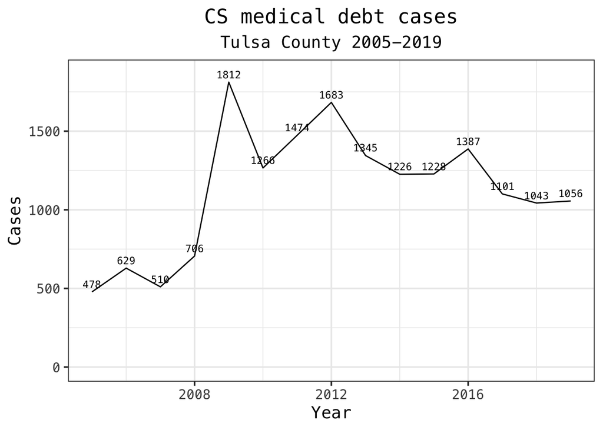

```r
ggplot(year_sum, aes(file_year, n)) +
  geom_line() +
  geom_text(aes(y = n + 50, label = n), family = "Menlo", size = 3) +
  xlab("Year") + ylab("Cases") +
  ylim(0, NA) +
  theme_ojo() +
  theme(plot.title = element_text(hjust = 0.5)) +
  theme(plot.subtitle = element_text(hjust = 0.5)) +
  labs(title = "CS medical debt cases",
       subtitle = "Tulsa County 2005-2019")
```

## 4.3 Summarizing by provider

```r
debt <- debt %>%
  mutate(plaint_cat = case_when(str_detect(iss_plaint, "SAINT FRANCIS") ~ "SAINT FRANCIS",
                                str_detect(iss_plaint, "ST JOHN") ~ "ST JOHN",
                                str_detect(iss_plaint, "HILLCREST") ~ "HILLCREST",
                                TRUE ~ "OTHER"))
```

Now we can see how many cases each group filed each year:

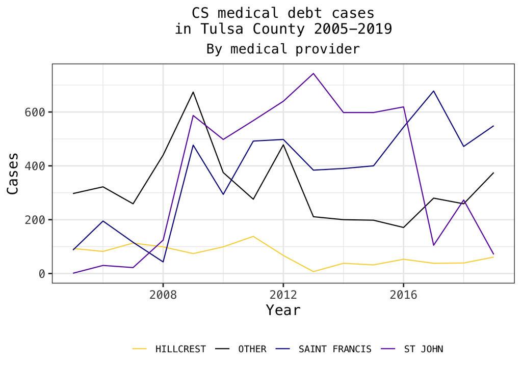

```r
plaint_sum <- debt %>%
  ungroup %>% # Our data frame is still grouped by casenum from the code above; ungroup to summarize using broader groups
  count(file_year, plaint_cat)

ggplot(plaint_sum, aes(file_year, n, group = plaint_cat, color = plaint_cat)) +
  geom_line() +
  xlab("Year") + ylab("Cases")+
  ylim(0, NA) + # Extends y-axis down to zero
  theme_ojo() + # Adds ojo styling to the plot
  theme(legend.title=element_blank())+
  theme(plot.title = element_text(hjust = 0.5, size = 14)) +
  theme(plot.subtitle = element_text(hjust = 0.5, size = 13)) +
  theme(legend.text=element_text(size = 9))+
  theme(legend.position="bottom")+
  labs(title = "CS medical debt cases\nin Tulsa County 2005-2019",
       subtitle = "By medical provider") +
  scale_color_manual(values = ojo_pal) # Gives lines colors from ojo's palette
```

### Find median debt amount

Created a new dataframe with the median medical debt amount by file_year.

```r
debt_new <- debt%>%
  group_by(file_year) %>%
  summarise(n_cases = n(),
            n_cases_with_debt = sum(!is.na(debt_amt)),
            avg = median(debt_amt, na.rm = TRUE)) %>%
  mutate(pct_with_debt = n_cases_with_debt/n_cases)

debt_new
```

```
## # A tibble: 15 x 5
##    file_year n_cases n_cases_with_debt   avg pct_with_debt
##        <int>   <int>             <int> <dbl>         <dbl>
##  1      2005     478                 0    NA             0
##  2      2006     629                 0    NA             0
##  3      2007     510                 0    NA             0
##  4      2008     706                 0    NA             0
##  5      2009    1812                 0    NA             0
##  6      2010    1266                 0    NA             0
##  7      2011    1474                 0    NA             0
##  8      2012    1683                 0    NA             0
##  9      2013    1345                 0    NA             0
## 10      2014    1226                 0    NA             0
## 11      2015    1228                 0    NA             0
## 12      2016    1387                 0    NA             0
## 13      2017    1101                 0    NA             0
## 14      2018    1043                 0    NA             0
## 15      2019    1056                 0    NA             0
```

### 4.3.1 Graph median medical debt by year

[figure not shown]

```r
ggplot(debt_new, aes(x= file_year, y= avg)) +
  geom_line() +
  #geom_text(aes(y = avg + 50, label = avg), family = "Menlo", size = 3) +
  xlab("Year") + ylab("Amount") +
  ylim(0, NA) + # Extends y-axis down to zero
  theme_ojo() +
  theme(plot.title = element_text(hjust = 0.5)) +
  theme(plot.subtitle = element_text(hjust = 0.5)) +
  labs(title = "Median medical debt amount CS",
       subtitle = "Tulsa County 2005-2019")
```